# Actividad 3

Equipo 3

2023-05-03

Alhelí Acosta de la Rosa // A01382195  
Ana Gabriela Sánchez Ruiz // A00828813  
Andrea Natalia Padilla Cedeño // A01197560  
Litzy Duque González // A01382189  
Rodrigo Gutiérrez Del Bosque // A01382212

## 0.1 Librerías

```r
##  Creación de campo llave para unir bases de datos
hospitales_2$clave <- NA

# 1 y 1
hospitales_2$clave <-  ifelse(hospitales_2$cve_ent < 10 & hospitales_2$cve_mun < 10, paste(hospitales_2$cve_ent, hospitales_2$cve_mun, sep = "00"), hospitales_2$clave)

# 1 y 2
hospitales_2$clave <- ifelse(hospitales_2$cve_ent < 10 & hospitales_2$cve_mun >= 10 & hospitales_2$cve_mun < 100, paste(hospitales_2$cve_ent, hospitales_2$cve_mun, sep = "0"), hospitales_2$clave)

# 1 y 3
hospitales_2$clave <- ifelse(hospitales_2$cve_ent < 10 &  hospitales_2$cve_mun >= 100, paste(hospitales_2$cve_ent, hospitales_2$cve_mun, sep = ""), hospitales_2$clave)

# 2 y 1
hospitales_2$clave <- ifelse(hospitales_2$cve_ent >= 10 & hospitales_2$cve_mun < 10, paste(hospitales_2$cve_ent, hospitales_2$cve_mun, sep = "00"), hospitales_2$clave)

# 2 y 2
hospitales_2$clave <- ifelse(hospitales_2$cve_ent >= 10 & hospitales_2$cve_mun < 100 & hospitales_2$cve_mun >= 10, paste(hospitales_2$cve_ent, hospitales_2$cve_mun, sep = "0"), hospitales_2$clave)

# 2 y 3
hospitales_2$clave <- ifelse(hospitales_2$cve_ent >= 10 & hospitales_2$cve_mun >= 100, paste(hospitales_2$cve_ent, hospitales_2$cve_mun, sep = ""), hospitales_2$clave)
```

```r
## Limpieza de na's
covid <- covid %>% mutate(across(where(is.numeric), ~replace_na(., median(., na.rm=TRUE))))
```

```r
# Join de las bases de datos con la cantidad de hospitales por municipio
hospitales_2$municipio <- as.factor(hospitales_2$municipio)
count_hospitales <- hospitales_2[ , c(11)]  %>% group_by(clave) %>% count(clave) %>% rename("hosp_num" = "n")

covid_2 <- merge(covid, count_hospitales, by.x = "cve_ent", by.y = "clave", all.x=TRUE)
```

```r
covid_2 <- merge(covid_2, municipio_estado, by.x = "cve_ent", by.y = "clave_municipio", all.x=TRUE)
```

```r
covid_2$hosp_numx10000 <- covid_2$hosp_num * 10000 / covid_2$poblacion_2022
```

```r
## Agrupar casos por año 2020 Y 2021
#Run once!!
covid_2 <- covid_2[ , -33]
columnas2020 <- covid_2[ , c(19:29)]
columnas2021 <- covid_2[ , c(30:41)]



covid_2$total2020 <- rowSums(columnas2020)
covid_2$total2021 <- rowSums(columnas2021)
## Promedio de ambas columnas 2020 y 2021
covid_2$avg_casos <- rowMeans(covid_2[, c(45,46)], na.rm=TRUE)

## Casos de Covid por cada 10,000 habitantes
covid_2$casosx10mil <- (covid_2$avg_casos/covid_2$poblacion_2022) * 10000
```

```r
covid_2$hogrem2015 <- covid_2$hogrem2015 / 100
covid_2$hogremjefmuj2015 <- covid_2$hogremjefmuj2015 / 100
covid_2$popnoafmed2015 <- covid_2$popnoafmed2015 / 100
covid_2$inclusion_fin_2019 <- covid_2$inclusion_fin_2019 / 100
covid_2$porcentaje_pob_pobreza <- covid_2$porcentaje_pob_pobreza / 100
covid_2$porcentaje_pob_pobreza_ext <- covid_2$porcentaje_pob_pobreza_ext / 100
covid_2$porcentaje_pob_servicios_salud <- covid_2$porcentaje_pob_servicios_salud / 100
covid_2$porcentaje_pob_acceso_ss <- covid_2$porcentaje_pob_acceso_ss / 100
covid_2$'pob_6-14_no_edu' <- covid_2$'pob_6-14_no_edu' / 100
```

```r
covid_boost <- covid_2[c('poblacion_2022','hogrem2015','hogremjefmuj2015',
                         'popnoafmed2015','gini2015','popden2020','crimen_2019',
                         'inclusion_fin_2019','porcentaje_pob_pobreza',
                         'porcentaje_pob_pobreza_ext','porcentaje_pob_servicios_salud',
                         'porcentaje_pob_acceso_ss','pob_6-14_no_edu','rezago_social',
                         'grado_rs','casosx10mil','hosp_numx10000')]
```

**XGboost**

```r
varImp(regressor)
```

```
## xgbTree variable importance
##
##                                  Overall
## rezago_social                  100.00000
## hogrem2015                      41.05680
## popden2020                      37.75332
## hosp_numx10000                  32.88772
## poblacion_2022                  31.14810
## porcentaje_pob_acceso_ss        22.29683
## inclusion_fin_2019              18.37479
## `pob_6-14_no_edu`               18.08460
## porcentaje_pob_pobreza          13.46710
## hogremjefmuj2015                11.92871
## porcentaje_pob_servicios_salud  11.47091
## porcentaje_pob_pobreza_ext      10.44292
## popnoafmed2015                   6.12473
## crimen_2019                      5.61152
## gini2015                         4.50907
## grado_rsBajo                     0.25779
## grado_rsMuy bajo                 0.04898
## grado_rsMedio                    0.03567
## grado_rsMuy alto                 0.00000
```

```r
library(janitor)
covid_tree <- clean_names(covid_boost)
regressor_2 <- train(casosx10mil ~ ., data= covid_tree, method = 'rpart2',preProcess = c("center", "scale"),na.action=na.pass)

varImp(regressor_2)
```

```
## rpart2 variable importance
##
##                                Overall
## inclusion_fin_2019             100.000
## hosp_numx10000                  95.199
## pob_6_14_no_edu                 92.596
## gini2015                        88.252
## porcentaje_pob_pobreza          86.268
## popden2020                      85.578
## popnoafmed2015                  80.529
## rezago_social                   66.596
## porcentaje_pob_pobreza_ext      59.486
## hogremjefmuj2015                59.014
## porcentaje_pob_acceso_ss        54.553
## hogrem2015                      46.873
## poblacion_2022                  45.045
## grado_rsMuy bajo                22.095
## grado_rsBajo                    13.038
## porcentaje_pob_servicios_salud   8.162
## `grado_rsMuy bajo`               0.000
## `grado_rsMuy alto`               0.000
## crimen_2019                      0.000
## grado_rsMedio                    0.000
```

## 0.2 Decision de variables

- rezago_social
- popden2020
- porcentaje_pob_acceso_ss
- porcentaje_pob_pobreza
- hogrem2015
- hosp_numx10000

**Filtrar por zona sur**

```r
zona_sur <- covid_3  %>% filter (entidad %in% c("Campeche", "Chiapas", "Guerrero", "Oaxaca", "Quintana Roo","Tabasco", "Veracruz", "Yucatan"))
```

### 0.2.1 DATA GEOESPACIAL

**GEO JOIN**

```r
mexico_geodata<-geo_join(map,covid_2,'IDUNICO','cve_ent',how='inner')
```

** join con zona sur**

```r
zona_sur_geodata <-geo_join(map1,zona_sur,'IDUNICO','cve_ent',how='inner')
```

```r
map_sur <- map_sur <-map1[map1$CVE_ENT == 4|map1$CVE_ENT == 7|map1$CVE_ENT == 12|map1$CVE_ENT == 20|map1$CVE_ENT == 23|map1$CVE_ENT == 27 | map1$CVE_ENT == 20 | map1$CVE_ENT == 31,]
lmat1 <- coordinates(map_sur)
names(lmat1) <- c("lon","lat")
map.centroid1 <- coordinates(map_sur)
```

## 0.3 Diferencias entre la estimación de modelo de regresión global y la estimación del método de Geographic Weighted Regression (GWR)

En el GWR agrega un nivel de sofisticación de modelado al permitir que las relaciones entre las variables independientes y dependientes varíen según la localidad y no por relación entre variables. El método GWR permite tomar en cuenta para el modelado variables no estacionarias como factores demográficos, clima, etc. El GWR a diferencia de un modelo de regresión global permite la interpolación de valores que no están incluidos en el conjunto de datos A diferencia de un modelo de regresión global GWR debe aplicarse a conjuntos de datos con varios cientos de características. No es un método apropiado para conjuntos de datos pequeños ya que no funciona con datos que son multipunto

## 0.4 Matrices de conectividad

## 0.5 MÉXICO

### 0.5.1 modelando vecinos espaciales y matrices de conectividad espacial:

```r
swm_queen <- poly2nb(map, queen = TRUE)
summary(swm_queen)
```

```
## Neighbour list object:
## Number of regions: 2456
## Number of nonzero links: 14392
## Percentage nonzero weights: 0.2385967
## Average number of links: 5.859935
## Link number distribution:
##
##   1   2   3   4   5   6   7   8   9  10  11  12  13  14  15  16  17  19  20  22
##   8  63 202 393 515 467 317 233 143  52  27  15   5   4   3   3   1   1   1   3
## 8 least connected regions:
## 299 354 667 858 930 1243 1461 2234 with 1 link
## 3 most connected regions:
## 966 1058 1173 with 22 links
```

```r
swm_rook <- poly2nb(map, queen = FALSE)
summary(swm_rook)
```

```
## Neighbour list object:
## Number of regions: 2456
## Number of nonzero links: 14176
## Percentage nonzero weights: 0.2350158
## Average number of links: 5.771987
## Link number distribution:
##
##   1   2   3   4   5   6   7   8   9  10  11  12  13  14  15  16  17  19  20  21
##   8  68 217 416 507 461 321 230 119  52  23  13   6   4   4   1   1   1   2   1
##  22
##   1
## 8 least connected regions:
## 299 354 667 858 930 1243 1461 2234 with 1 link
## 1 most connected region:
## 1058 with 22 links
```

### 0.5.2 Mapeando “queen contiguity” basado en mapas de vecinos

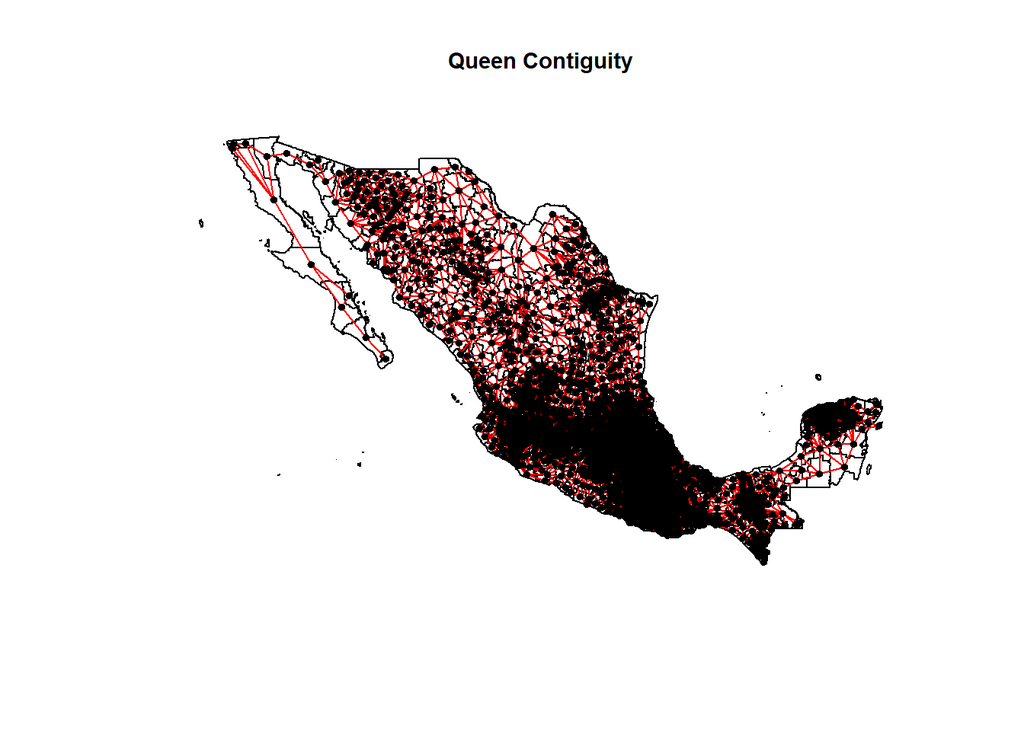

```r
suppressWarnings({
plot(map, borders = 'lightgrey')
plot(swm_queen, coordinates(map), pch = 19, cex = 0.6, add = TRUE, col = "red")
title(main = "Queen Contiguity", cex.main = 0.9)
})
```

### Mapeando “rook contiguity” basad en neighbors maps Como podemos ver los resultados de la matriz de conectividad son muy similares que al mapearlo con enfoque de contiguedad rook

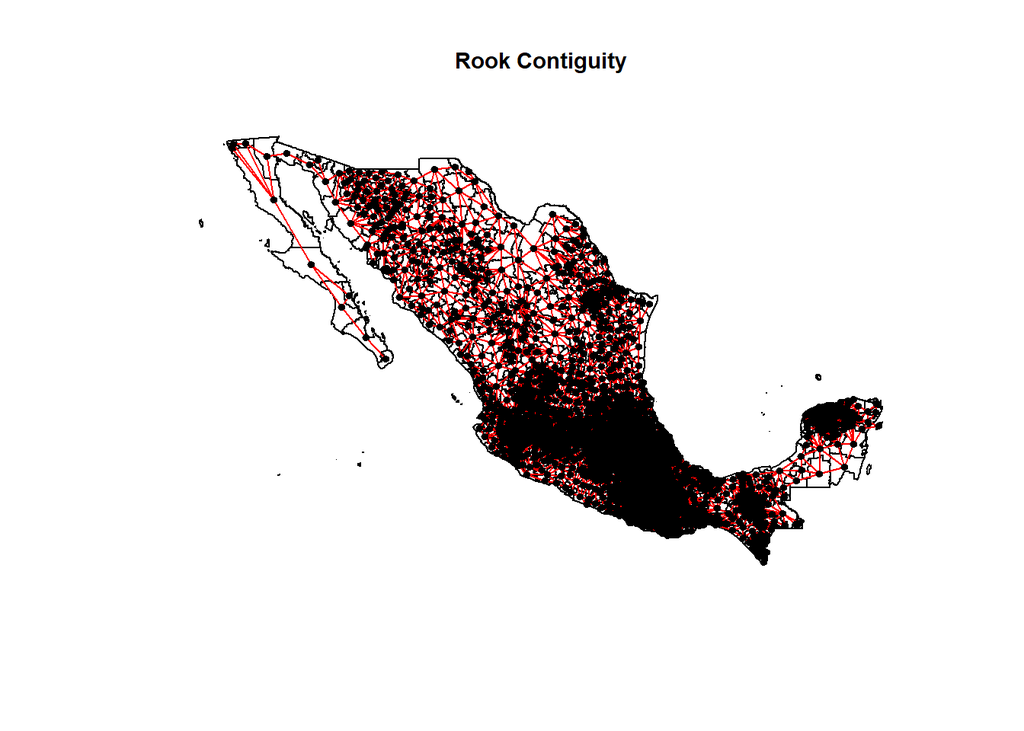

```r
suppressWarnings({
plot(map, borders = 'lightgrey')
plot(swm_rook, coordinates(map), pch = 19, cex = 0.6, add = TRUE, col = "red")
title(main = "Rook Contiguity", cex.main = 0.9)
})
```

### 0.5.3 calculando distancia basada en los vecinos

Aquí vamos a calcular las medidas de tendencia central de nuestras distancias hacia los vecinos para más adelante poder mapearlos

```r
coords <- coordinates(map)
head(coords)
```

```
##        [,1]     [,2]
## 0 -99.20622 19.19834
## 1 -99.09036 19.24515
## 2 -99.26841 19.26898
## 3 -99.18211 19.48533
## 4 -99.16113 19.38064
## 5 -99.14906 19.43137
```

```r
knn1 <- knn2nb(knearneigh(coords))
knn1_dist <- unlist(nbdists(knn1, coords, longlat = TRUE))
summary(knn1_dist)
```

```
##    Min. 1st Qu.  Median    Mean 3rd Qu.    Max.
##   0.558   7.387  11.413  15.811  19.110 229.364
```

```r
dwm <- dnearneigh(coords, 0 ,229, longlat = TRUE)
dwm
```

```
## Neighbour list object:
## Number of regions: 2456
## Number of nonzero links: 1158018
## Percentage nonzero weights: 19.19811
## Average number of links: 471.5057
## 1 region with no links:
## 353
```

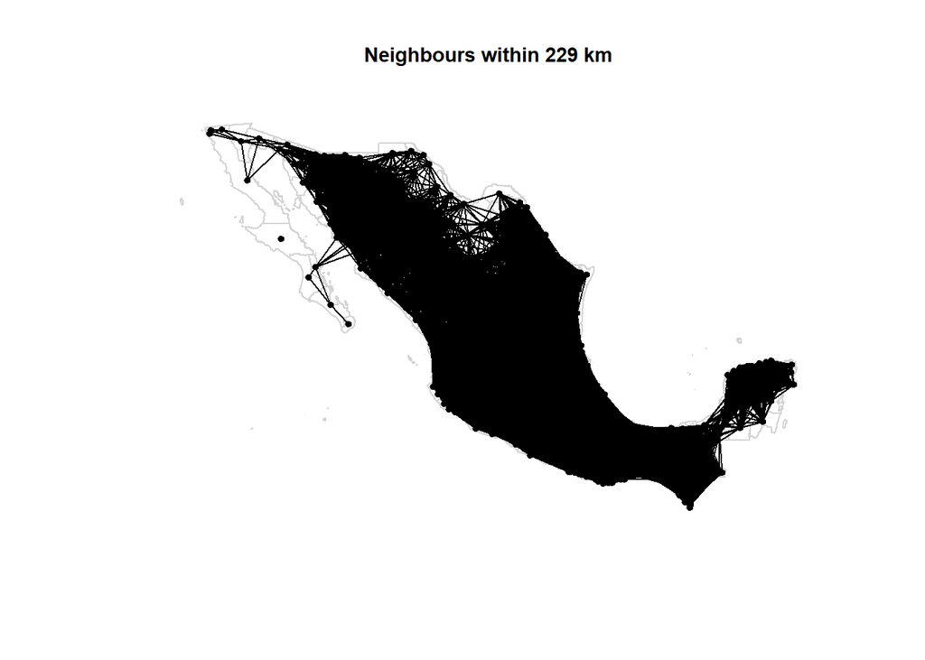

```r
plot(map, border = "lightgrey")
plot(dwm, coords, add = TRUE, pch = 19, cex = 0.6)
title(main = "Neighbours within 229 km", cex.main = 0.9)
```

```r
rswm_queen <- nb2listw(swm_queen, style = "W", zero.policy = TRUE)
rswm_queen
```

```
## Characteristics of weights list object:
## Neighbour list object:
## Number of regions: 2456
## Number of nonzero links: 14392
## Percentage nonzero weights: 0.2385967
## Average number of links: 5.859935
##
## Weights style: W
## Weights constants summary:
##      n      nn   S0       S1       S2
## W 2456 6031936 2456 898.7549 10338.48
```

## 0.6 ZONA SUR

### 0.6.1 modelando vecinos espaciales y matrices de conectividad espacial:

```r
swm_queen_sur <- poly2nb(map_sur, queen = TRUE)
summary(swm_queen_sur)
```

```
## Neighbour list object:
## Number of regions: 912
## Number of nonzero links: 5200
## Percentage nonzero weights: 0.6251924
## Average number of links: 5.701754
## Link number distribution:
##
##   1   2   3   4   5   6   7   8   9  10  11  12  13  15  16  17  19  20  22
##   7  47  85 146 195 154 109  81  45  13  13   3   4   2   2   1   1   1   3
## 7 least connected regions:
## 858 930 1075 1123 1243 1461 1464 with 1 link
## 3 most connected regions:
## 966 1058 1173 with 22 links
```

```r
swm_rook_sur <- poly2nb(map_sur, queen = FALSE)
summary(swm_rook_sur)
```

```
## Neighbour list object:
## Number of regions: 912
## Number of nonzero links: 5062
## Percentage nonzero weights: 0.6086007
## Average number of links: 5.550439
## Link number distribution:
##
##   1   2   3   4   5   6   7   8   9  10  11  12  13  14  15  16  17  19  20  21
##   7  50  95 157 192 156 113  69  33  14   9   3   4   1   2   1   1   1   2   1
##  22
##   1
## 7 least connected regions:
## 858 930 1075 1123 1243 1461 1464 with 1 link
## 1 most connected region:
## 1058 with 22 links
```

### 0.6.2 Mapeando “queen contiguity” basado en mapas de vecinos Zona Sur

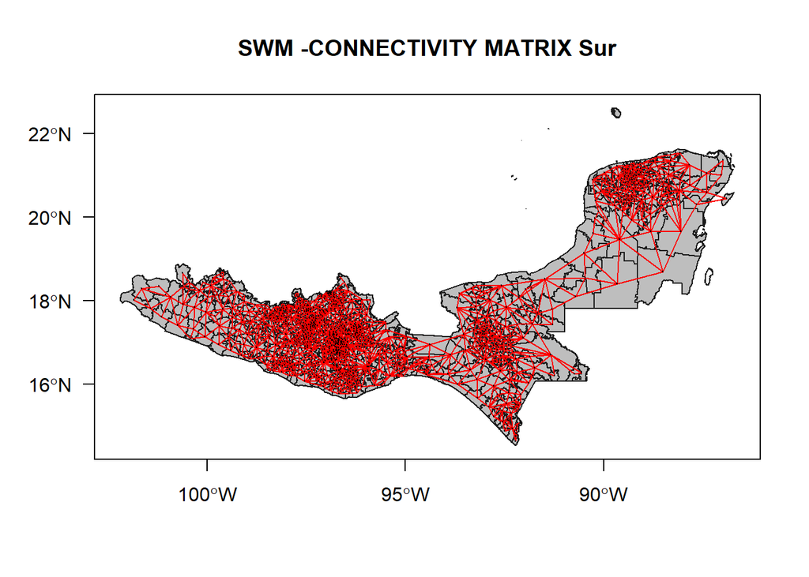

```r
map.link_a_queen1<-poly2nb(map_sur,queen=T)
map.linkW_a_queen1<-nb2listw(map.link_a_queen1, style="W")
plot(map_sur,border="blue",axes=TRUE,las=1)
plot(map_sur,col="grey",border=grey(0.11),axes=T,add=T)
plot(map.linkW_a_queen1,coords=map.centroid1,pch=19,cex=0.1,col="red",add=T)
title("SWM -CONNECTIVITY MATRIX Sur")
box()
```

### 0.6.3 Mapeando “rook contiguity” basad en neighbors maps

Como podemos ver los resultados de la matriz de conectividad son muy similares que al mapearlo con enfoque de contiguedad rook

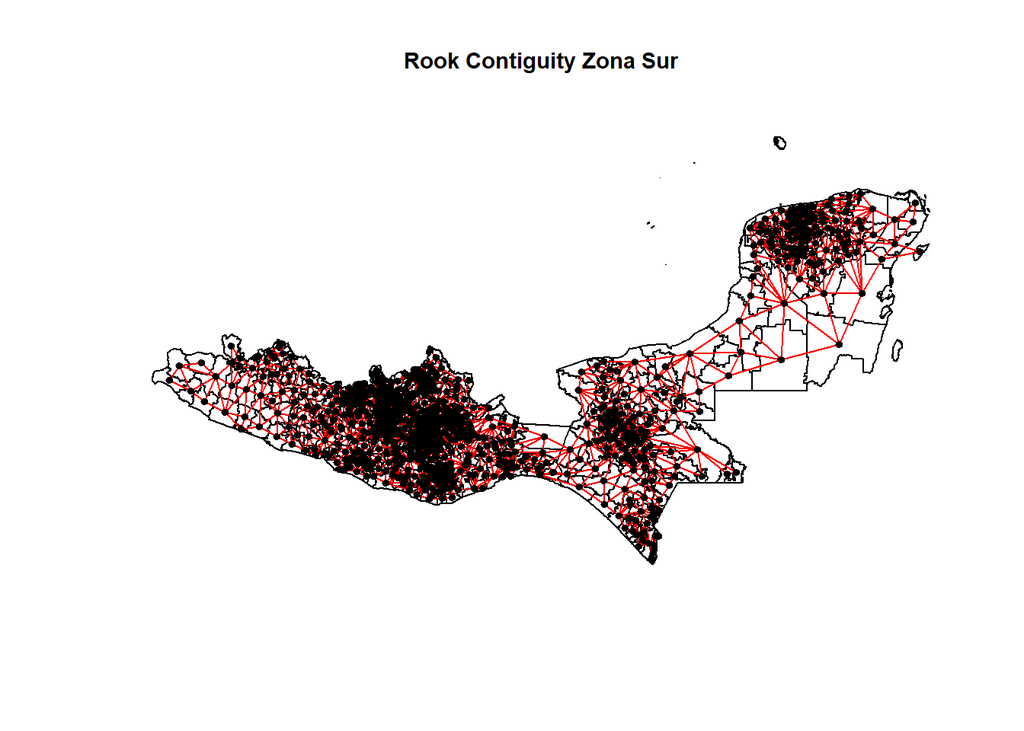

```r
suppressWarnings({
plot(map_sur, borders = 'lightgrey')
plot(swm_rook_sur, coordinates(map_sur), pch = 19, cex = 0.6, add = TRUE, col = "red")
title(main = "Rook Contiguity Zona Sur", cex.main = 0.9)
})
```

### 0.6.4 calculando distancia basada en los vecinos

Aquí vamos a calcular las medidas de tendencia central de nuestras distancias hacia los vecinos para más adelante poder mapearlos

```r
coords_sur <- coordinates(map_sur)
head(coords_sur)
```

```
##          [,1]     [,2]
## 16  -99.98090 18.09123
## 17  -99.71366 18.13230
## 18  -99.81470 18.12476
## 19  -99.11236 17.52369
## 20  -99.69745 17.39083
## 21 -100.10417 18.44113
```

```r
knn2 <- knn2nb(knearneigh(coords_sur))
knn2_dist <- unlist(nbdists(knn2, coords_sur, longlat = TRUE))
summary(knn2_dist)
```

```
##    Min. 1st Qu.  Median    Mean 3rd Qu.    Max.
##   0.558   5.863   9.228  11.746  14.266 111.525
```

```r
dwm2 <- dnearneigh(coords_sur, 0 ,111, longlat = TRUE)
dwm2
```

```
## Neighbour list object:
## Number of regions: 912
## Number of nonzero links: 160288
## Percentage nonzero weights: 19.27131
## Average number of links: 175.7544
## 1 region with no links:
## 904
```

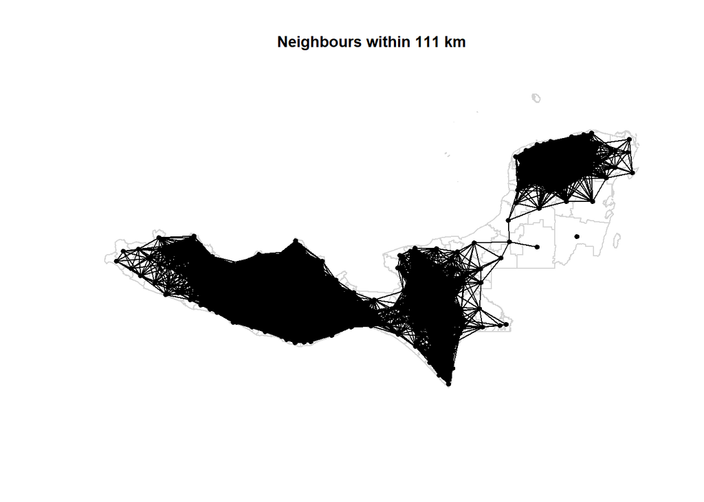

```r
plot(map_sur, border = "lightgrey")
plot(dwm2, coords_sur, add = TRUE, pch = 19, cex = 0.6)
title(main = "Neighbours within 111 km", cex.main = 0.9)
```

Elaborar ESDA a partir del rezago espacial de 3-5 variables. Identificar la posible presencia de autocorrelación espacial en las variables seleccionadas.

# 1 3. ESDA

Elaborar ESDA a partir del rezago espacial de 3-5 variables. Identificar la posible presencia de autocorrelación espacial en las variables seleccionadas.

```r
rswm_queen_sur <- nb2listw(swm_queen_sur, style = "W", zero.policy = TRUE)
rswm_queen_sur
```

```
## Characteristics of weights list object:
## Neighbour list object:
## Number of regions: 912
## Number of nonzero links: 5200
## Percentage nonzero weights: 0.6251924
## Average number of links: 5.701754
##
## Weights style: W
## Weights constants summary:
##     n     nn  S0       S1       S2
## W 912 831744 912 351.3113 3909.732
```

```r
rswm_rook_sur <- nb2listw(swm_rook_sur, style = "W", zero.policy = TRUE)
rswm_rook_sur
```

```
## Characteristics of weights list object:
## Neighbour list object:
## Number of regions: 912
## Number of nonzero links: 5062
## Percentage nonzero weights: 0.6086007
## Average number of links: 5.550439
##
## Weights style: W
## Weights constants summary:
##     n     nn  S0       S1       S2
## W 912 831744 912 359.8708 3918.354
```

## 1.1 Spatial Lag (Rezago espacial) con queen contiguity

### 1.1.1 Variable 1: ‘Casosx10mil’

```r
### lets create a spatial lag of dataset's variable
zona_sur_geodata$sp_casosx10mil<-lag.listw(rswm_queen_sur,zona_sur_geodata$casosx10mil,zero.policy=TRUE)
# texas_geodata$sp_median_household_income
```

```r
casosx10mil <- qtm(zona_sur_geodata, "casosx10mil")
spatial_lag_casosx10mil <- qtm(zona_sur_geodata, "sp_casosx10mil")
```

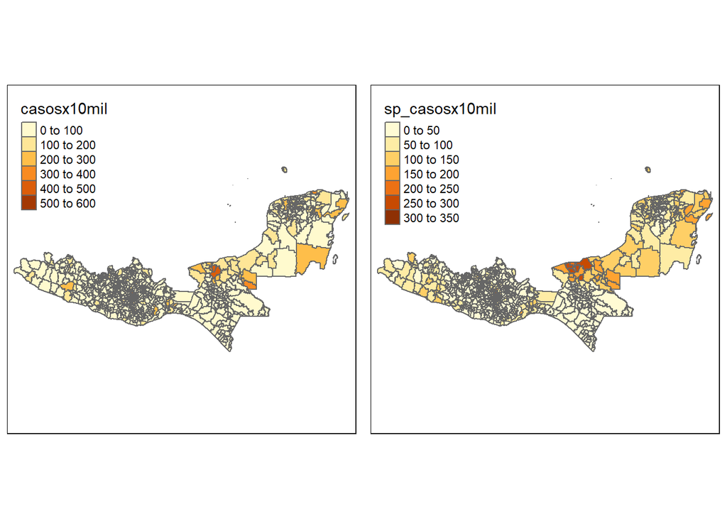

```r
tmap_arrange(casosx10mil, spatial_lag_casosx10mil, asp = 1, ncol =2)
```

```r
#+ title('Spatial Lagged Variables')
```

### 1.1.2 Presencia de autocorrelación espacial en Casosx10mil

```r
### identifying and measuring spatial autocorrelation

# Moran's I Test
moran.test(zona_sur_geodata$casosx10mil, listw = rswm_queen_sur, zero.policy = TRUE, na.action = na.omit)
```

```
##
##  Moran I test under randomisation
##
## data:  zona_sur_geodata$casosx10mil
## weights: rswm_queen_sur
##
## Moran I statistic standard deviate = 26.284, p-value < 2.2e-16
## alternative hypothesis: greater
## sample estimates:
## Moran I statistic       Expectation          Variance
##      0.5348694743     -0.0010976948      0.0004158094
```

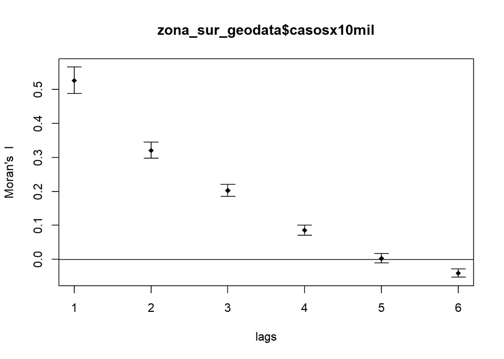

```r
# Computing Moran’s I correlogram
Moran_Correlogram <- sp.correlogram(swm_queen_sur, zona_sur_geodata$casosx10mil, order = 6, method = "I", style = "B")
plot(Moran_Correlogram)
```

### 1.1.3 Variable 2: ‘hosp_numx10000’

```r
### lets create a spatial lag of dataset's variable
zona_sur_geodata$sp_hosp_numx10000<-lag.listw(rswm_queen_sur,zona_sur_geodata$hosp_numx10000,zero.policy=TRUE)
# texas_geodata$sp_median_household_income
```

```r
hosp_numx10000 <- qtm(zona_sur_geodata, "hosp_numx10000")
spatial_lag_hosp_numx10000<- qtm(zona_sur_geodata, "sp_hosp_numx10000")
```

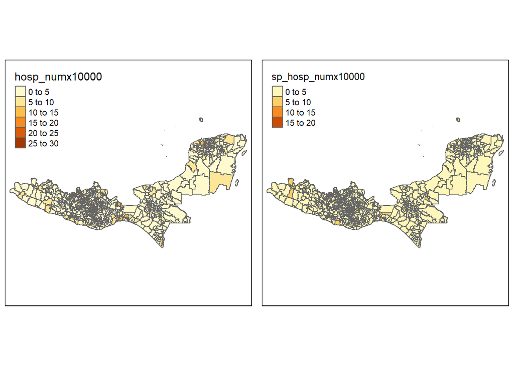

```r
tmap_arrange(hosp_numx10000, spatial_lag_hosp_numx10000, asp = 1, ncol =2)
```

```r
#+ title('Spatial Lagged Variables')
```

## 1.2 Presencia de autocorrelación

```r
### identifying and measuring spatial autocorrelation

# Moran's I Test
moran.test(zona_sur_geodata$hosp_numx10000, listw = rswm_queen_sur, zero.policy = TRUE, na.action = na.omit)
```

```
##
##  Moran I test under randomisation
##
## data:  zona_sur_geodata$hosp_numx10000
## weights: rswm_queen_sur
##
## Moran I statistic standard deviate = 10.324, p-value < 2.2e-16
## alternative hypothesis: greater
## sample estimates:
## Moran I statistic       Expectation          Variance
##      0.2089228038     -0.0010976948      0.0004138498
```

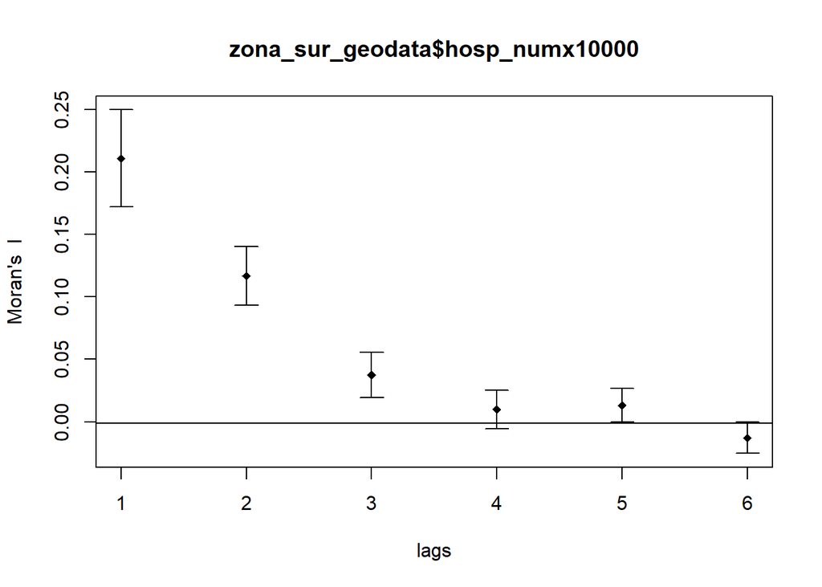

```r
# Computing Moran’s I correlogram
Moran_Correlogram <- sp.correlogram(swm_queen_sur, zona_sur_geodata$hosp_numx10000, order = 6, method = "I", style = "B")
plot(Moran_Correlogram)
```

### 1.2.1 Variable 3: ‘popden2020’

```r
### lets create a spatial lag of dataset's variable
zona_sur_geodata$sp_popden2020<-lag.listw(rswm_queen_sur,zona_sur_geodata$popden2020,zero.policy=TRUE)
# texas_geodata$sp_median_household_income
```

```r
popden2020 <- qtm(zona_sur_geodata, "popden2020")
spatial_lag_popden2020 <- qtm(zona_sur_geodata, "popden2020")
```

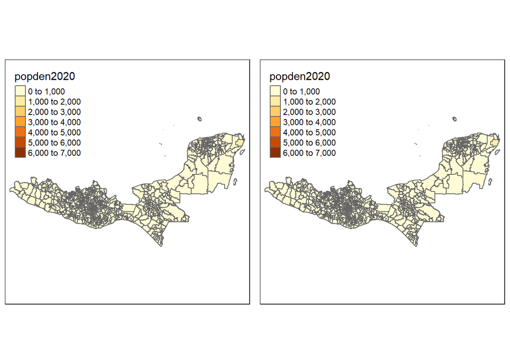

```r
tmap_arrange(popden2020, spatial_lag_popden2020, asp = 1, ncol =2)
```

```r
#+ title('Spatial Lagged Variables')
```

## 1.3 Presencia de autocorrelación

```r
### identifying and measuring spatial autocorrelation

# Moran's I Test
moran.test(zona_sur_geodata$popden2020, listw = rswm_queen_sur, zero.policy = TRUE, na.action = na.omit)
```

```
##
##  Moran I test under randomisation
##
## data:  zona_sur_geodata$popden2020
## weights: rswm_queen_sur
##
## Moran I statistic standard deviate = 25.292, p-value < 2.2e-16
## alternative hypothesis: greater
## sample estimates:
## Moran I statistic       Expectation          Variance
##      0.4494750571     -0.0010976948      0.0003173641
```

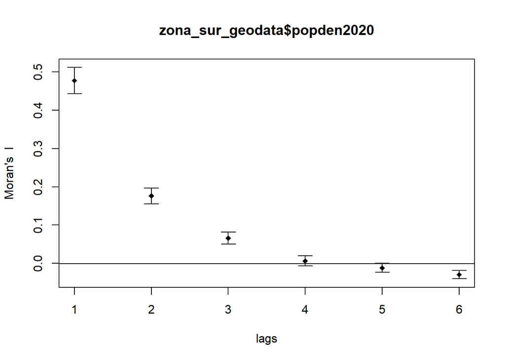

```r
# Computing Moran’s I correlogram
Moran_Correlogram <- sp.correlogram(swm_queen_sur, zona_sur_geodata$popden2020, order = 6, method = "I", style = "B")
plot(Moran_Correlogram)
```

### 1.3.1 Variable 4: ‘porcentaje_pob_acceso_ss’

```r
### lets create a spatial lag of dataset's variable
zona_sur_geodata$sp_porcentaje_pob_acceso_ss<-lag.listw(rswm_queen_sur,zona_sur_geodata$porcentaje_pob_acceso_ss,zero.policy=TRUE)
# texas_geodata$sp_median_household_income
```

```r
porcentaje_pob_acceso_ss <- qtm(zona_sur_geodata, "porcentaje_pob_acceso_ss")
spatial_lag_porcentaje_pob_acceso_ss <- qtm(zona_sur_geodata, "sp_porcentaje_pob_acceso_ss")
```

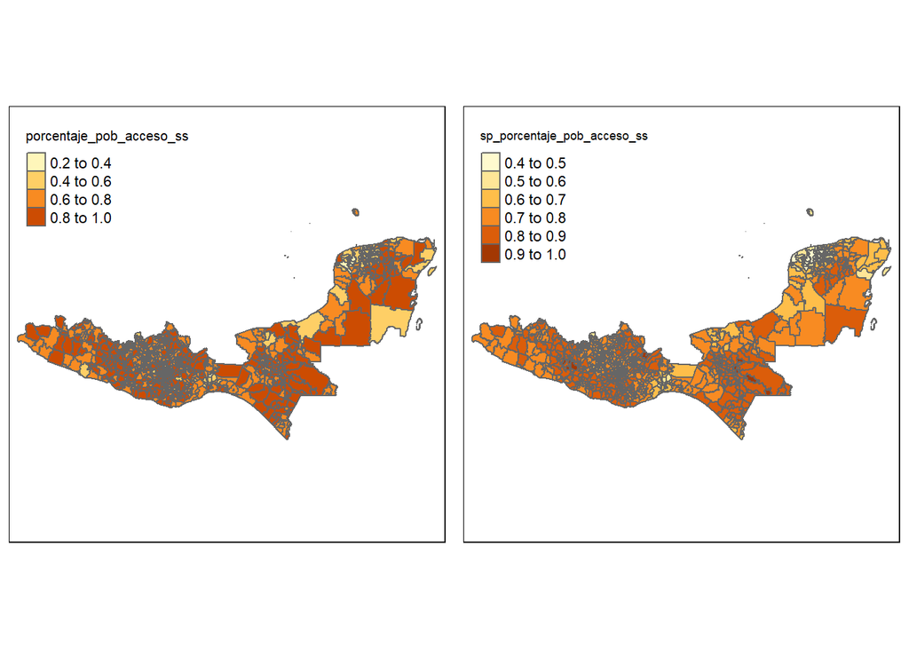

```r
tmap_arrange(porcentaje_pob_acceso_ss, spatial_lag_porcentaje_pob_acceso_ss, asp = 1, ncol =2)
```

```r
#+ title('Spatial Lagged Variables')
```

## 1.4 Presencia de autocorrelación

```r
### identifying and measuring spatial autocorrelation

# Moran's I Test
moran.test(zona_sur_geodata$porcentaje_pob_acceso_ss, listw = rswm_queen_sur, zero.policy = TRUE, na.action = na.omit)
```

```
##
##  Moran I test under randomisation
##
## data:  zona_sur_geodata$porcentaje_pob_acceso_ss
## weights: rswm_queen_sur
##
## Moran I statistic standard deviate = 23.977, p-value < 2.2e-16
## alternative hypothesis: greater
## sample estimates:
## Moran I statistic       Expectation          Variance
##      0.4897484248     -0.0010976948      0.0004190757
```

[figure not shown]

```r
# Computing Moran’s I correlogram
Moran_Correlogram <- sp.correlogram(swm_queen_sur, zona_sur_geodata$casosx10mil, order = 6, method = "I", style = "B")
plot(Moran_Correlogram)
```

## 1.5 Spatial Lag (Rezago espacial) con rook contiguity

### 1.5.1 Variable 1: ‘Casosx10mil’

```r
### lets create a spatial lag of dataset's variable
zona_sur_geodata$sp_casosx10mil<-lag.listw(rswm_rook_sur,zona_sur_geodata$casosx10mil,zero.policy=TRUE)
# texas_geodata$sp_median_household_income
```

```r
casosx10mil <- qtm(zona_sur_geodata, "casosx10mil")
spatial_lag_casosx10mil <- qtm(zona_sur_geodata, "sp_casosx10mil")
```

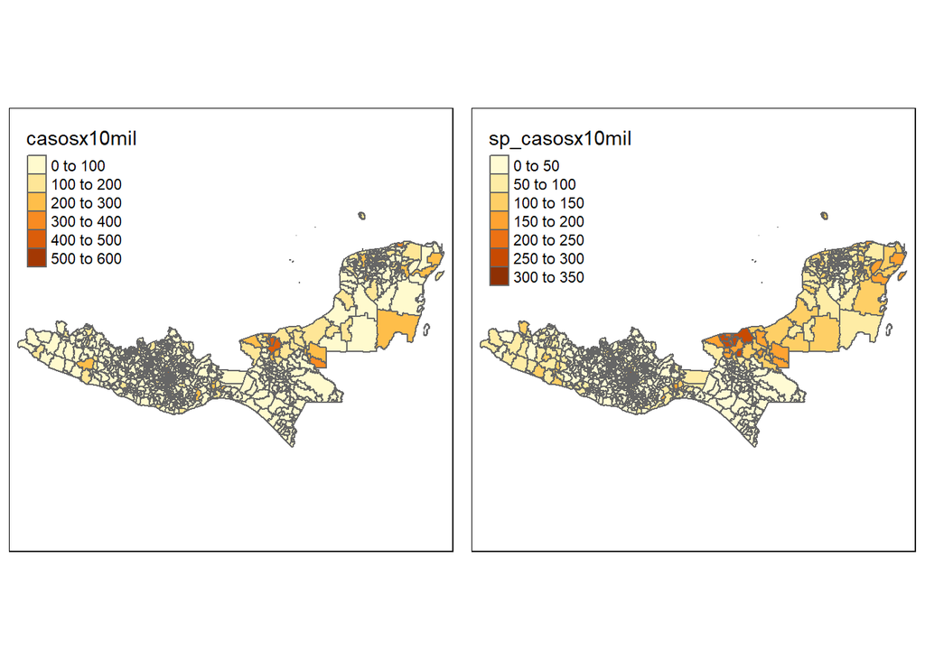

```r
tmap_arrange(casosx10mil, spatial_lag_casosx10mil, asp = 1, ncol =2)
```

```r
#+ title('Spatial Lagged Variables')
```

### 1.5.2 Presencia de autocorrelación espacial en Casosx10mil

```r
### identifying and measuring spatial autocorrelation

# Moran's I Test
moran.test(zona_sur_geodata$casosx10mil, listw = rswm_rook_sur, zero.policy = TRUE, na.action = na.omit)
```

```
##
##  Moran I test under randomisation
##
## data:  zona_sur_geodata$casosx10mil
## weights: rswm_rook_sur
##
## Moran I statistic standard deviate = 26.103, p-value < 2.2e-16
## alternative hypothesis: greater
## sample estimates:
## Moran I statistic       Expectation          Variance
##      0.5376594505     -0.0010976948      0.0004259956
```

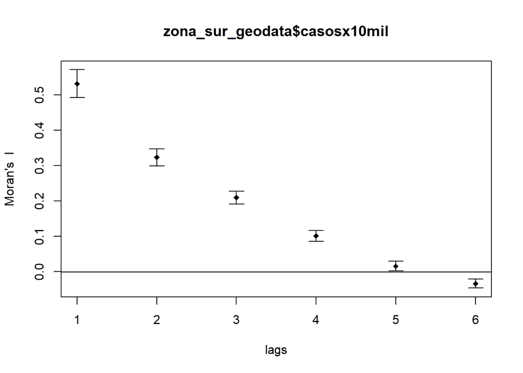

```r
# Computing Moran’s I correlogram
Moran_Correlogram <- sp.correlogram(swm_rook_sur, zona_sur_geodata$casosx10mil, order = 6, method = "I", style = "B")
plot(Moran_Correlogram)
```

### 1.5.3 Variable 2: ‘hosp_numx10000’

```r
### lets create a spatial lag of dataset's variable
zona_sur_geodata$sp_hosp_numx10000<-lag.listw(rswm_rook_sur,zona_sur_geodata$hosp_numx10000,zero.policy=TRUE)
# texas_geodata$sp_median_household_income
```

```r
hosp_numx10000 <- qtm(zona_sur_geodata, "hosp_numx10000")
spatial_lag_hosp_numx10000<- qtm(zona_sur_geodata, "sp_hosp_numx10000")
```

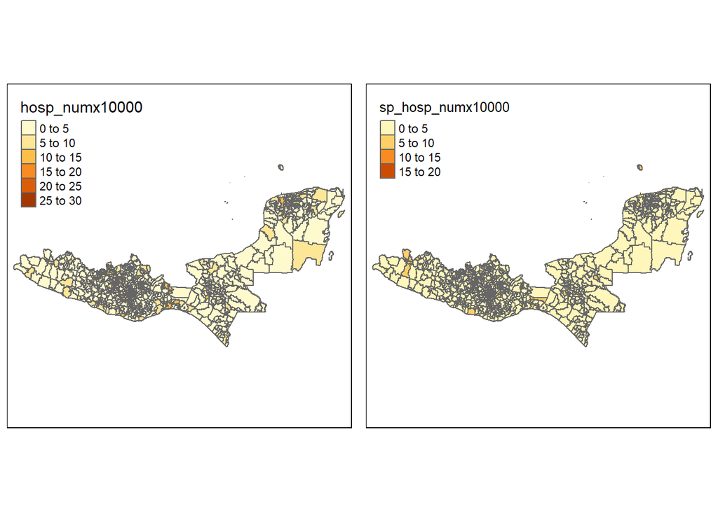

```r
tmap_arrange(hosp_numx10000, spatial_lag_hosp_numx10000, asp = 1, ncol =2)
```

```r
#+ title('Spatial Lagged Variables')
```

## 1.6 Presencia de autocorrelación

```r
### identifying and measuring spatial autocorrelation

# Moran's I Test
moran.test(zona_sur_geodata$hosp_numx10000, listw = rswm_rook_sur, zero.policy = TRUE, na.action = na.omit)
```

```
##
##  Moran I test under randomisation
##
## data:  zona_sur_geodata$hosp_numx10000
## weights: rswm_rook_sur
##
## Moran I statistic standard deviate = 10.257, p-value < 2.2e-16
## alternative hypothesis: greater
## sample estimates:
## Moran I statistic       Expectation          Variance
##       0.210096231      -0.001097695       0.000423988
```

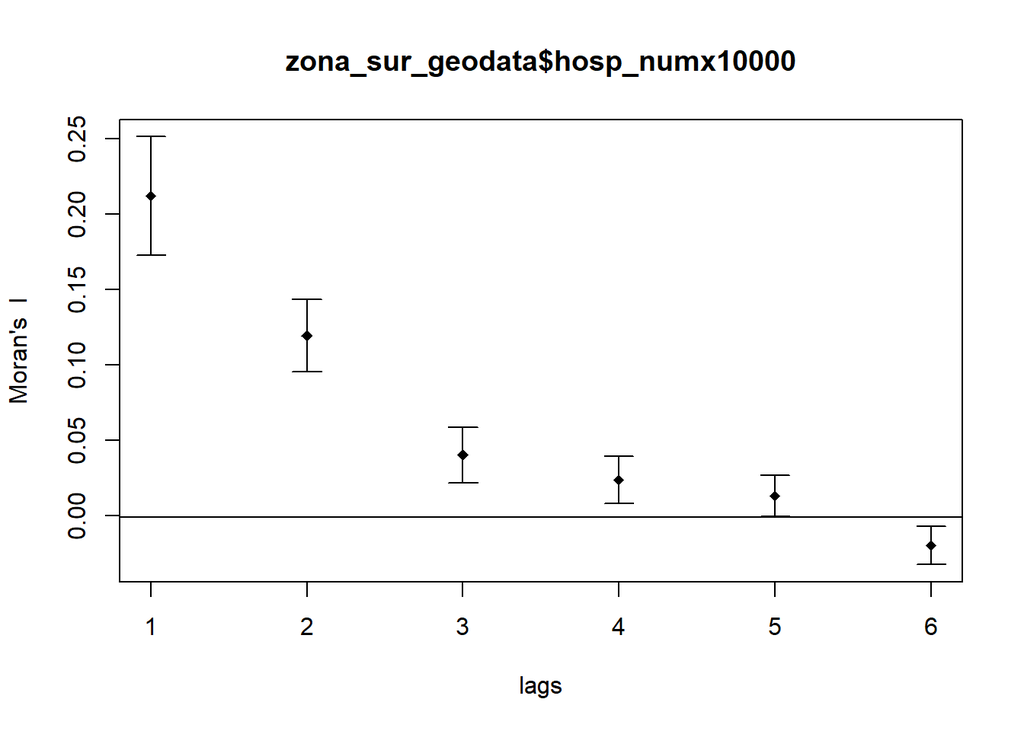

```r
# Computing Moran’s I correlogram
Moran_Correlogram <- sp.correlogram(swm_rook_sur, zona_sur_geodata$hosp_numx10000, order = 6, method = "I", style = "B")
plot(Moran_Correlogram)
```

### 1.6.1 Variable 3: ‘popden2020’

```r
### lets create a spatial lag of dataset's variable
zona_sur_geodata$sp_popden2020<-lag.listw(rswm_rook_sur,zona_sur_geodata$popden2020,zero.policy=TRUE)
# texas_geodata$sp_median_household_income
```

```r
popden2020 <- qtm(zona_sur_geodata, "popden2020")
spatial_lag_popden2020 <- qtm(zona_sur_geodata, "popden2020")
```

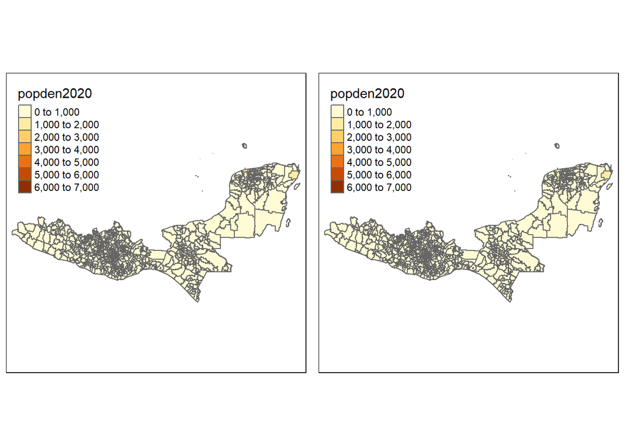

```r
tmap_arrange(popden2020, spatial_lag_popden2020, asp = 1, ncol =2)
```

```r
#+ title('Spatial Lagged Variables')
```

## 1.7 Presencia de autocorrelación

```r
### identifying and measuring spatial autocorrelation

# Moran's I Test
moran.test(zona_sur_geodata$popden2020, listw = rswm_rook_sur, zero.policy = TRUE, na.action = na.omit)
```

```
##
##  Moran I test under randomisation
##
## data:  zona_sur_geodata$popden2020
## weights: rswm_rook_sur
##
## Moran I statistic standard deviate = 25.25, p-value < 2.2e-16
## alternative hypothesis: greater
## sample estimates:
## Moran I statistic       Expectation          Variance
##      0.4542060147     -0.0010976948      0.0003251393
```

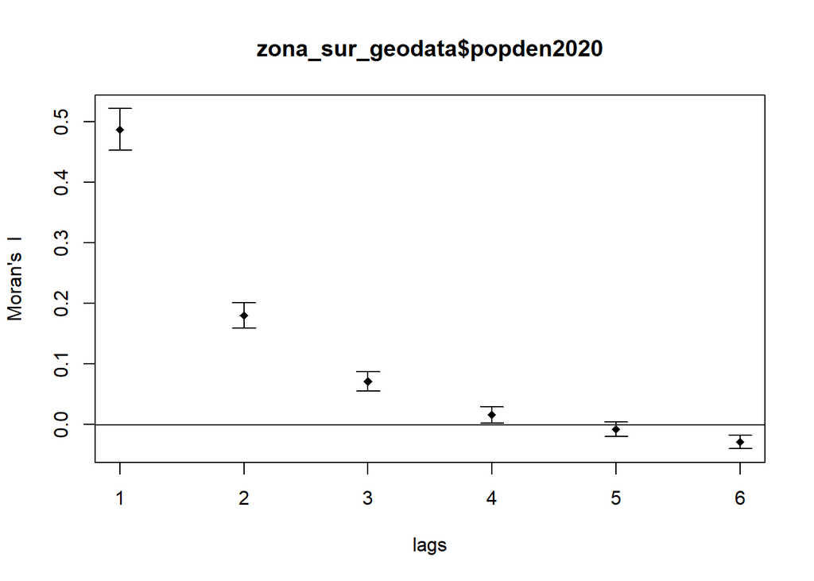

```r
# Computing Moran’s I correlogram
Moran_Correlogram <- sp.correlogram(swm_rook_sur, zona_sur_geodata$popden2020, order = 6, method = "I", style = "B")
plot(Moran_Correlogram)
```

### 1.7.1 Variable 4: ‘porcentaje_pob_acceso_ss’

```r
### lets create a spatial lag of dataset's variable
zona_sur_geodata$sp_porcentaje_pob_acceso_ss<-lag.listw(rswm_rook_sur,zona_sur_geodata$porcentaje_pob_acceso_ss,zero.policy=TRUE)
# texas_geodata$sp_median_household_income
```

```r
porcentaje_pob_acceso_ss <- qtm(zona_sur_geodata, "porcentaje_pob_acceso_ss")
spatial_lag_porcentaje_pob_acceso_ss <- qtm(zona_sur_geodata, "sp_porcentaje_pob_acceso_ss")
```

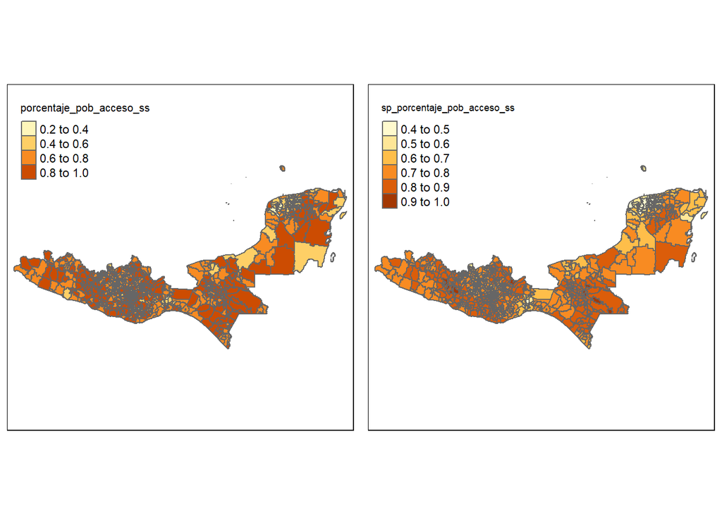

```r
tmap_arrange(porcentaje_pob_acceso_ss, spatial_lag_porcentaje_pob_acceso_ss, asp = 1, ncol =2)
```

```r
#+ title('Spatial Lagged Variables')
```